**Análisis Geoestadístico análisis del modelo Gausiano para concentraciones de zinc**

Los datos meuse contienen información sobre la ubicación y concentraciones de metales pesados en la capa superior del suelo, junto con una serie de variables de suelo y paisaje en los lugares de observación, recogidas en una llanura del río Meuse, cerca del pueblo de Stein.

**Análisis exploratorio**

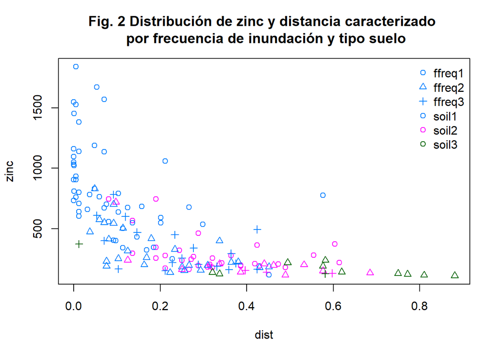

Figure 2 : Presenta la dependencia entre la concentración de zinc sobre la distancia de río, frecuencia de las innundaciones y el tipo de suelo.

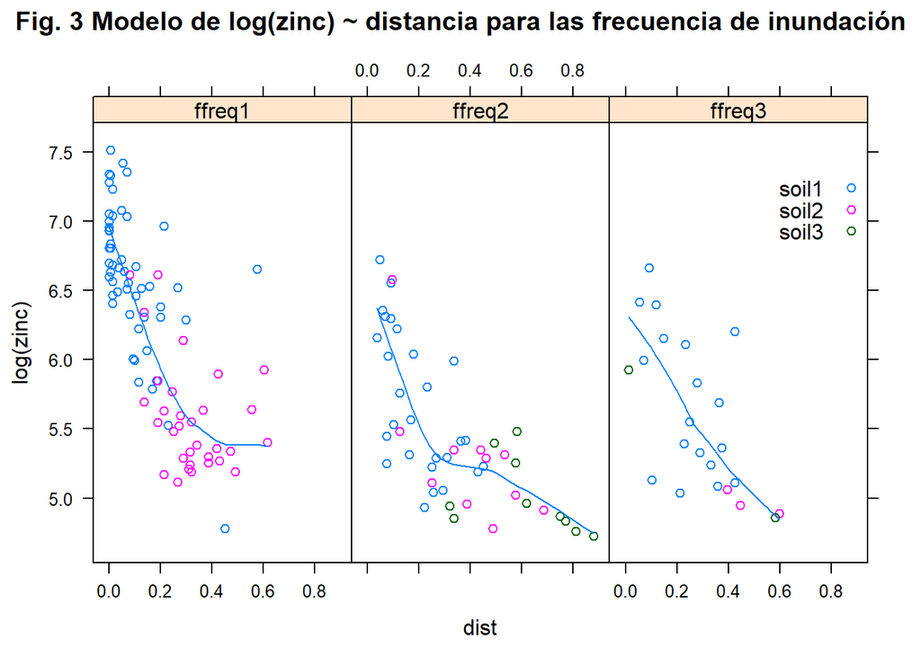

En la figura 3 se muestra la correción con la función logaritmica sobre dependencia entre la concentración de zinc sobre la distancia de río, frecuencia de las innundaciones y el tipo de suelo. La relación aún no es lineal, para corregir se transforma de la raíz cuadrada en la distancia en el río.

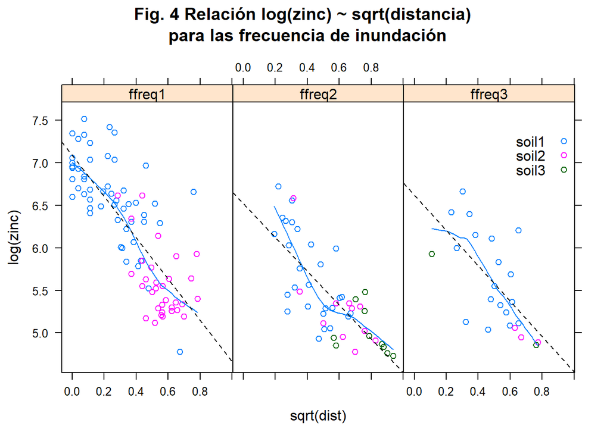

Mediante la transformación se puede observar que las pendientes de las líneas de regresión log (zinc) ~ sqrt (dist) son casi iguales para todos los niveles de frecuencia de inundaciones.

| Modelo log (zinc) ~ sqrt (dist) term | Modelo log (zinc) ~ sqrt (dist) estimate | Modelo log (zinc) ~ sqrt (dist) std.error | Modelo log (zinc) ~ sqrt (dist) statistic | Modelo log (zinc) ~ sqrt (dist) p.value |
| --- | --- | --- | --- | --- |
| (Intercept) | 7,0298677 | 0,0714109 | 98,442486 | 0,0000000 |
| sqrt(dist) | -2,2660166 | 0,1558527 | -14,539475 | 0,0000000 |
| ffreqffreq2 | -0,3605368 | 0,0786486 | -4,584147 | 0,0000095 |
| ffreqffreq3 | -0,3166713 | 0,0981557 | -3,226213 | 0,0015382 |

**Diagnóstico de los gráficos de residuos**

A continuación se presenta un diagnostico de los residuos para corroborar los supuestos de los del modelo, validando la normalidad, homocedasticidad, valores atipicos y valores influenciales.

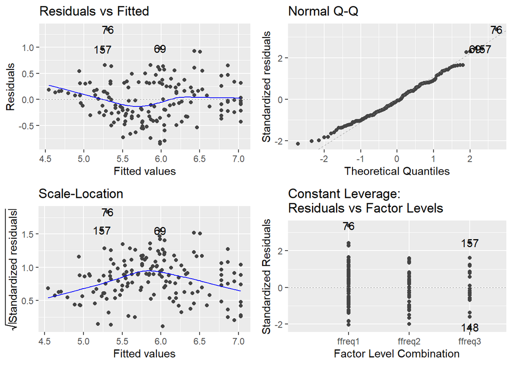

Los gráficos de residuos no muestran violación de los supuestos, en los residuos en comparación con los ajustados se comprueba que los residuos se distribuyen aleatoriamente con varianza constante, de la misma forma los residuos estandarizados presentan una distribución normal observada en el gráfico de normalidad.

El siguiente gráfico, muestra el variograma de los residuos para las 4 direcciones Norte-Sur, Noreste-Sureste, Este-Oeste, Sureste-Noreste por el método de estimación de momentos

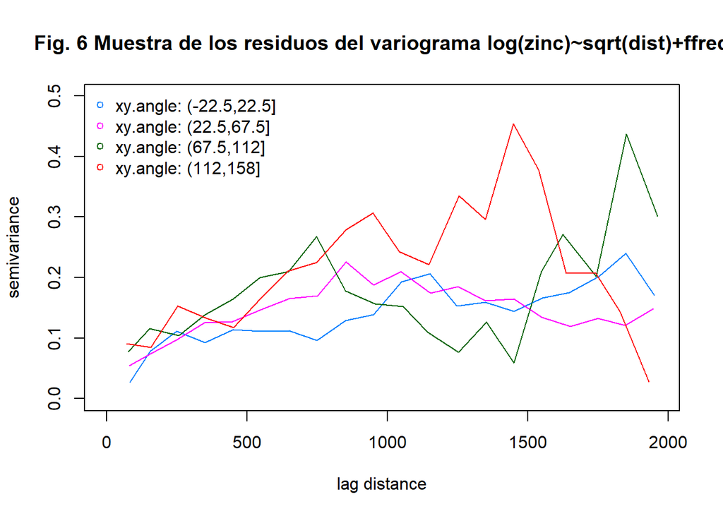

En la figura 6, el variograma de muestra dependiente de la dirección de los residuos de regresión para el modelo log (zinc) ~ sqrt (dist) + ffreq.

Los residuos parecen ser espacialmente dependientes. Para los rezagos cortos no existe una dependencia clara de la dirección, por lo tanto, suponemos que la autocorrelación es isotrópica.

Para completar el ejercicio de modelado exploratorio, se calcula el variograma de muestra independiente de la dirección y ajustamos un modelo de variograma esférico por mínimos cuadrados no lineales ponderados, usando los pesos de Cressie’s.

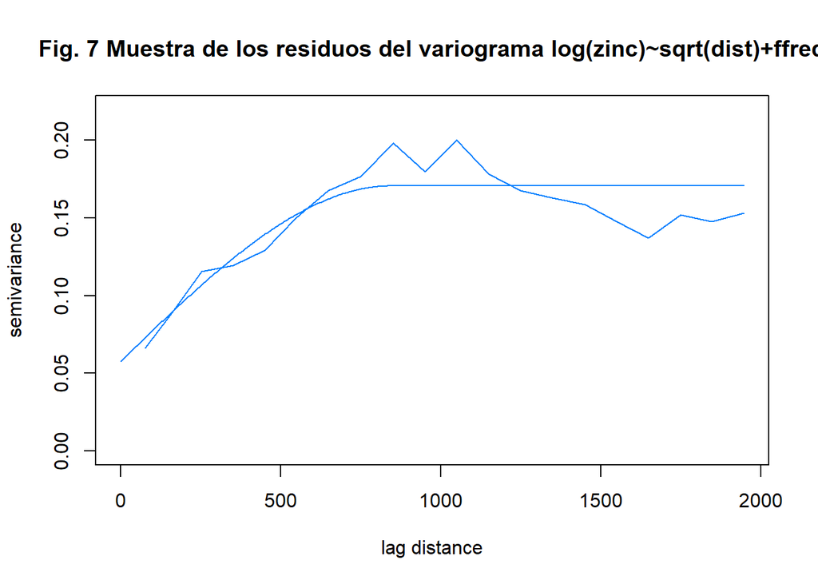

La figura 7 muestra el variograma de los residuos para el modelo de regresión definido por log (zinc) ~ sqrt (dist) + ffreq, utilizando la función de variograma esférico ajustado

| Modelo regresión de los residuos log (zinc) ~ sqrt (dist) .rownames | Modelo regresión de los residuos log (zinc) ~ sqrt (dist) Estimate | Modelo regresión de los residuos log (zinc) ~ sqrt (dist) Lower | Modelo regresión de los residuos log (zinc) ~ sqrt (dist) Upper |
| --- | --- | --- | --- |
| variance | 0,1128315 | 0,1035647 | 0,1229274 |
| snugget(fixed) | 0,0000000 | NA | NA |
| nugget | 0,0576871 | 0,0490423 | 0,0678556 |
| scale | 844,2341633 | 767,1049812 | 929,1183605 |

Ajuste del modelo lineal espacial mediante un modelo gausianno de máxima verosimilitud (RE)

Se ajusta el modelo por Gaussian REML y se obtienen los siguientes resultados:

| Modelo regresión coeficientes ajustado Gaussian REML .rownames | Modelo regresión coeficientes ajustado Gaussian REML Estimate | Modelo regresión coeficientes ajustado Gaussian REML Std..Error | Modelo regresión coeficientes ajustado Gaussian REML t.value | Modelo regresión coeficientes ajustado Gaussian REML Pr…t.. |
| --- | --- | --- | --- | --- |
| (Intercept) | 7,0889352 | 0,1391098 | 50,959297 | 0e+00 |
| sqrt(dist) | -2,1318610 | 0,2590317 | -8,230117 | 0e+00 |
| ffreqffreq2 | -0,5268223 | 0,0689407 | -7,641672 | 0e+00 |
| ffreqffreq3 | -0,5382798 | 0,1040171 | -5,174919 | 7e-07 |

| Modelo regresión de los residuos log (zinc) ~ sqrt (dist) .rownames | Modelo regresión de los residuos log (zinc) ~ sqrt (dist) Estimate | Modelo regresión de los residuos log (zinc) ~ sqrt (dist) Lower | Modelo regresión de los residuos log (zinc) ~ sqrt (dist) Upper |
| --- | --- | --- | --- |
| variance | 0,1349238 | 0,0677478 | 0,2687091 |
| snugget(fixed) | 0,0000000 | NA | NA |
| nugget | 0,0550799 | 0,0327061 | 0,0927592 |
| scale | 876,5812103 | 746,9212119 | 1.028,7492255 |

**Especificación del modelo**

```
## $variogram.model
## [1] "RMspheric"
##
## $param
##     variance      snugget       nugget        scale
##   0.13492383   0.00000000   0.05507986 876.58121029
##
## $fit.param
## variance  snugget   nugget    scale
##     TRUE    FALSE     TRUE     TRUE
##
## $isotropic
## [1] TRUE
##
## $aniso
##    f1    f2 omega   phi  zeta
##     1     1    90    90     0
##
## $fit.aniso
##    f1    f2 omega   phi  zeta
## FALSE FALSE FALSE FALSE FALSE
##
## $sincos
## $sincos$co
## [1] 6.123032e-17
##
## $sincos$so
## [1] 1
##
## $sincos$cp
## [1] 6.123032e-17
##
## $sincos$sp
## [1] 1
##
## $sincos$cz
## [1] 1
##
## $sincos$sz
## [1] 0
##
##
## $rotmat
##               [,1]         [,2]
## [1,]  1.000000e+00 6.123032e-17
## [2,] -6.123032e-17 1.000000e+00
##
## $sclmat
##    f1
##  1  1
```

Los resultado de la máximización de la probabilidad de verosimilitud por nlminb es exitosa. Sin embargo, antes de interpretar, se calcula la probabilidad de registro del perfil para el rango para ver si la maximización ha encontrado el máximo global.

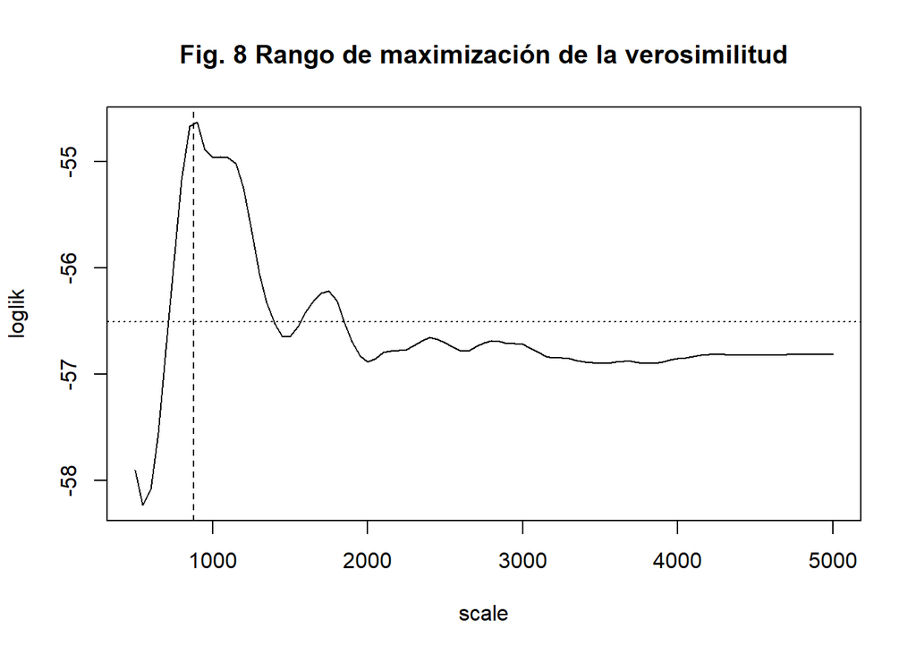

En la figura 8, se muestra la probabilidad de verosimilitud por el parámetro de rango de escala, del variograma esférico (línea vertical: estimación de la escala devuelta por georob (); la intersección de la línea horizontal con el perfil define una región de confianza del 95% para la escala basada en la prueba de razón de verosimilitud).

Aunque la probabilidad restringida de log verosimilitud es multimodal, que a menudo se observa para modelos de variograma con soporte compacto, se encontra el máximo global porque los valores iniciales de los parámetros del variograma estaban cerca de las estimaciones REML. Las estimaciones de escala (rango de variograma) y varianza (umbral parcial) nugget y escala están correlacionadas.

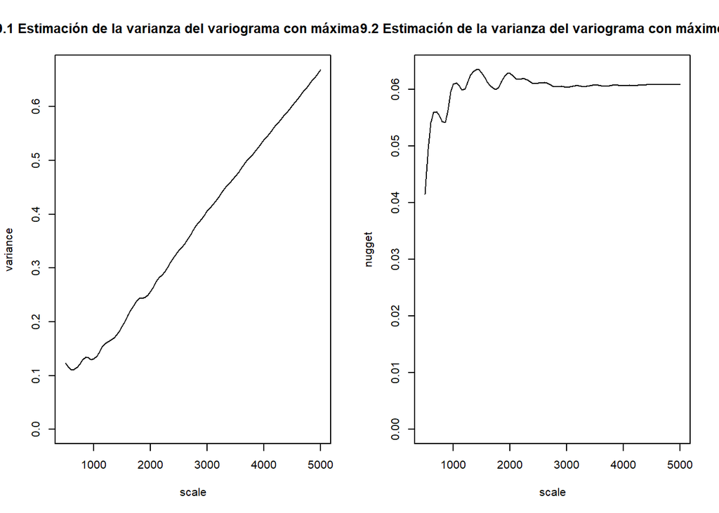

La figura 9.1, presenta las estimaciones de varianza (umbral parcial) y nugget en función de la estimación del rango (escala) del variograma.

Ahora nos interesa el resultado de los parámetros estimados del variograma junto con los intervalos de confianza del 95% que se calculan en función de la distribución asintótica normal de las estimaciones de (RE) ML a partir de la información de Fisher observada. La dependencia de log (zinc) en sqrt (dist) es altamente significativa, al igual que la dependencia de la frecuencia de inundaciones.

| Prueba wald Información de Fischer res.df | Prueba wald Información de Fischer df | Prueba wald Información de Fischer statistic | Prueba wald Información de Fischer p.value |
| --- | --- | --- | --- |
| 151 | NA | NA | NA |
| 153 | -2 | 31,18138 | 0 |

Se puede probar la igualdad de todos los pares de intercepciones por funciones del paquete multcomp

| Prueba de pares lhs | Prueba de pares rhs | Prueba de pares estimate | Prueba de pares std.error | Prueba de pares statistic | Prueba de pares p.value |
| --- | --- | --- | --- | --- | --- |
| ffreq1 - ffreq2 | 0 | 0,5268223 | 0,0689407 | 7,6416724 | 0,0000000 |
| ffreq1 - ffreq3 | 0 | 0,5382798 | 0,1040171 | 5,1749187 | 0,0000005 |
| ffreq2 - ffreq3 | 0 | 0,0114576 | 0,0959712 | 0,1193854 | 0,9920004 |

Como se sospecha, solo la intercepción de ffreq1 difiere de las demás. Agregar la interacción sqrt (dist): ffreq no mejora el modelo

| Prueba wald Información de Fischer distancia y inundaciones res.df | Prueba wald Información de Fischer distancia y inundaciones df | Prueba wald Información de Fischer distancia y inundaciones statistic | Prueba wald Información de Fischer distancia y inundaciones p.value |
| --- | --- | --- | --- |
| 151 | NA | NA | NA |
| 149 | 2 | 0,6753757 | 0,5105162 |

| Prueba wald Información de Fischer Suelo res.df | Prueba wald Información de Fischer Suelo df | Prueba wald Información de Fischer Suelo statistic | Prueba wald Información de Fischer Suelo p.value |
| --- | --- | --- | --- |
| 151 | NA | NA | NA |
| 149 | 2 | 2,268142 | 0,107067 |

Los modelos también se pueden construir mediante una selección de covariables paso a paso con el criterio en AIC, ya sea manteniendo los parámetros del variograma fijos (por defecto) o volviendo a estimarlos de nuevo para cada modelo evaluado

```
## Start:  AIC=106.91
## log(zinc) ~ sqrt(dist) + ffreq
##
##                    Df    AIC Converged
## <none>                106.91
## + soil              2 107.20         1
## + ffreq:sqrt(dist)  2 109.72         1
## - ffreq             2 166.39         1
## - sqrt(dist)        1 178.01         1
```

```
##
## Tuning constant:  1000
##
## Fixed effects coefficients:
## (Intercept)   sqrt(dist)  ffreqffreq2  ffreqffreq3
##      7.0938      -2.1459      -0.5263      -0.5368
##
## Variogram:  RMspheric
##  variance(fixed)    snugget(fixed)     nugget(fixed)      scale(fixed)
##          0.12299           0.00000           0.05597         872.39971
```

```
## Start:  AIC=112.91
## log(zinc) ~ sqrt(dist) + ffreq
##
##                    Df    AIC Converged
## <none>                112.91         1
## + soil              2 113.11         1
## + ffreq:sqrt(dist)  2 115.63         1
## - sqrt(dist)        1 144.28         1
## - ffreq             2 158.21         1
```

```
##
## Tuning constant:  1000
##
## Fixed effects coefficients:
## (Intercept)   sqrt(dist)  ffreqffreq2  ffreqffreq3
##      7.0938      -2.1459      -0.5263      -0.5368
##
## Variogram:  RMspheric
##         variance    snugget(fixed)            nugget             scale
##          0.12299           0.00000           0.05597         872.39971
```

La selección de covariables paso a paso por la función step.georob, add1.georob y drop1.georob() requiere la probabilidad de verosimilitud no restringida. Antes de evaluar los modelos candidatos, ML ajusta el modelo inicial, se hace de la siguiente forma

```
## [1]   7.0000 123.1674
```

Los modelos se comparan mediante validación cruzada

```
##
## Statistics of cross-validation prediction errors
##        me       mede       rmse       made        qne       msse
## -0.009512  -0.035082   0.372749   0.357945   0.360882   0.972375
##    medsse       crps
##  0.379926   0.208286
##
## Statistics of back-transformed cross-validation prediction errors
##       me      mede      rmse      made       qne      msse    medsse
## -18.4060  -33.7740  196.9399  144.0156  143.7456    1.0639    0.3068
```

```
##
## Statistics of cross-validation prediction errors
##      me     mede     rmse     made      qne     msse   medsse     crps
## 0.04183  0.03423  0.43470  0.40486  0.40773  1.03625  0.41027  0.23985
##
## Statistics of back-transformed cross-validation prediction errors
##       me      mede      rmse      made       qne      msse    medsse
##  14.3101  -22.8901  220.8882  142.4411  147.1828    1.6038    0.3179
```

Tenga en cuenta que el argumento $lng = TRUE$ tiene el efecto de que las predicciones de validación cruzada de una respuesta transformada logarítmica se transforman nuevamente a la escala original de las mediciones.

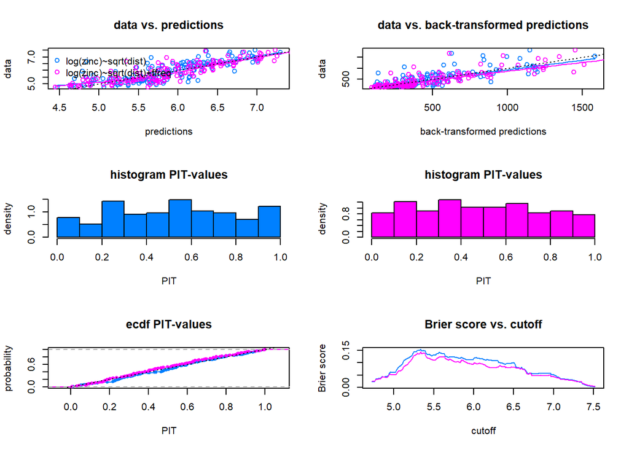

La figura 10 muestra los gráficos de diagnóstico de predicciones de validación cruzada con ajustes REML de modelos log (zinc) ~ sqrt (dist) (azul) y log (zinc) ~ sqrt (dist) + ffreq (magenta).

Terminamos el modelado trazando diagnósticos residuales del modelo. $r.georob.m0.spher.reml$ y comparando el variograma estimado con la estimación de ML y el modelo ajustado previamente al variograma de muestra de residuos de mínimos cuadrados ordinarios (MCO)

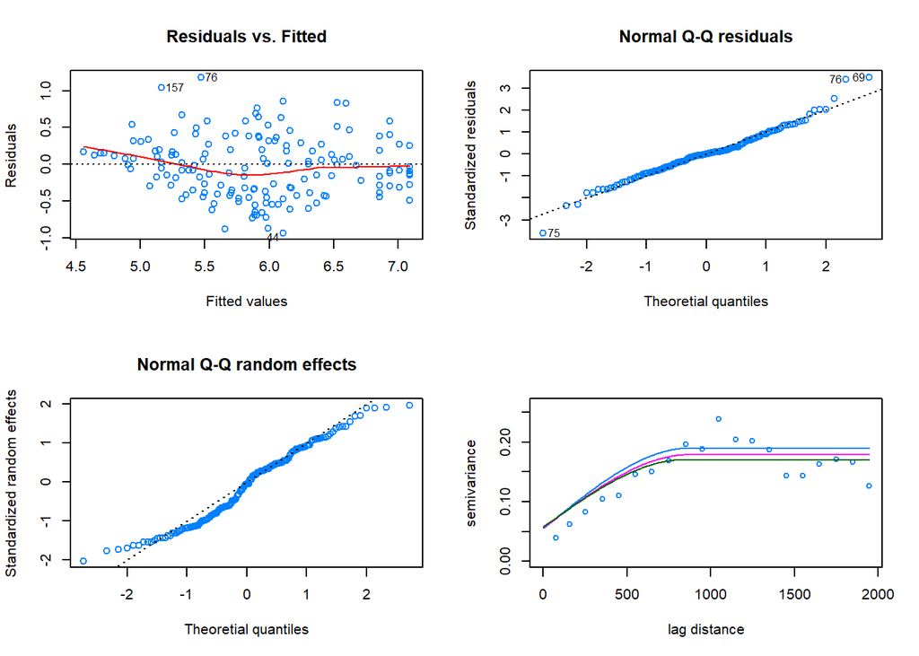

La figura 11, presenta los gráficos de diagnóstico residual del modelo de registro (zinc) ~ sqrt (dist) + ffreq y variograma esférico estimado por REML (azul), ML (magenta) y ajustado al variograma de muestra (verde oscuro).

Como se esperaba, REML estima un rango mayor y parámetros de umbral parcial. Las gráficas de diagnóstico no revelan violaciones graves de los supuestos de modelado.